# W13：類別資料分析——卡方檢定

心理教育統計 2026

授課教師：陳紹慶 | e-mail: csc2009@mail.tcu.edu.tw

2026/05/25

# 本週學習目標

**理解概念**：

1. 理解**觀測值 vs 預期值**的概念
2. 掌握**適合度檢定**與**獨立性檢定**
3. 解讀 **Cramer’s V** 效果量
4. 區分 **t 檢定**（比平均）vs **卡方檢定**（比比例）

**jamovi操作**：

1. 執行 **Frequencies → N Outcomes**（適合度）
2. 執行 **Frequencies → Contingency Tables**（獨立性）
3. 計算Expected Counts 與 Cramer’s V
4. APA 格式的卡方檢定報告

## 對應教材

- 《用 jamovi 上手統計學》
  - [第 10 章：類別資料分析](https://scgeeker.github.io/lsj-book-zh_tw/10-Categorical-data-analysis.html)

**簡報示範資料**：

- Randomness：花色選擇 200 次（適合度檢定）
- Chapek9：物種 × 選擇偏好（獨立性檢定）

**操作示範資料**： - “Study2_copy.xls”, [前置處理操作錄影](https://www.youtube.com/live/_UPqXWh1-Bs?si=12PvmLH83MUL_8Q2&t=5119)

**作業資料**：個人化 `W13_Survey_[學號].csv`

# Part 1：觀測值與預期值🧠

## 從直覺到統計

**日常直覺**：擲硬幣 100 次

- **預期**：正面 50 次、反面 50 次
- **實際**：正面 70 次、反面 30 次
- **問題**：這個差距是「運氣」還是「硬幣不公平」？

**卡方檢定的核心**：

$$\chi^2 = \sum \frac{(O -
E)^2}{E}$$

- $O$：觀測值（Observed）— 實際看到的
- $E$：預期值（Expected）— 假設為真時的期望
- 差距越大 → $\chi^2$ 越大 → 越不像巧合
- $\chi^2$ 統計量的取樣分佈（H₀ 成立且預期次數 ≥5 時）近似卡方分佈

## 卡方分佈的特性

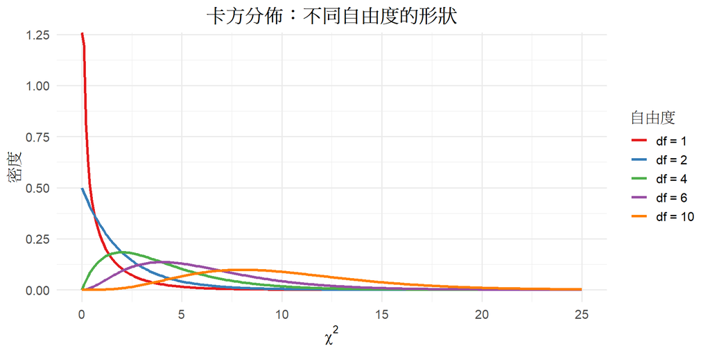

## 卡方分佈的關鍵特徵

| 特徵 | 說明 |
| --- | --- |
| 只有正值 | $\chi^2 \geq 0$（平方後不可能為負） |
| 右偏分佈 | 低 df 時明顯右偏，高 df 時趨近常態 |
| df 決定形狀 | df 越大 → 分佈越對稱、越往右移 |
| 平均值 = df | $E(\chi^2) = df$ |

> 與 t 分佈不同之處：卡方**沒有負值**，且**不對稱**

# Part 2：適合度檢定🧠

## 花色選擇是否均等？

**情境**：200 位參與者從 4 種花色中任選一個（clubs / diamonds / hearts / spades），結果如下：

200 次花色選擇：觀測值 vs 預期值

| 花色 | 觀測次數 | 預期次數 |
| --- | --- | --- |
| clubs | 35 | 50 |
| diamonds | 51 | 50 |
| hearts | 64 | 50 |
| spades | 50 | 50 |

- **$H_0$**：花色選擇均等（選任何花色機率 = 1/4）
- **$H_1$**：花色選擇不均等（某花色被偏好）

## 觀測 vs 預期的視覺化

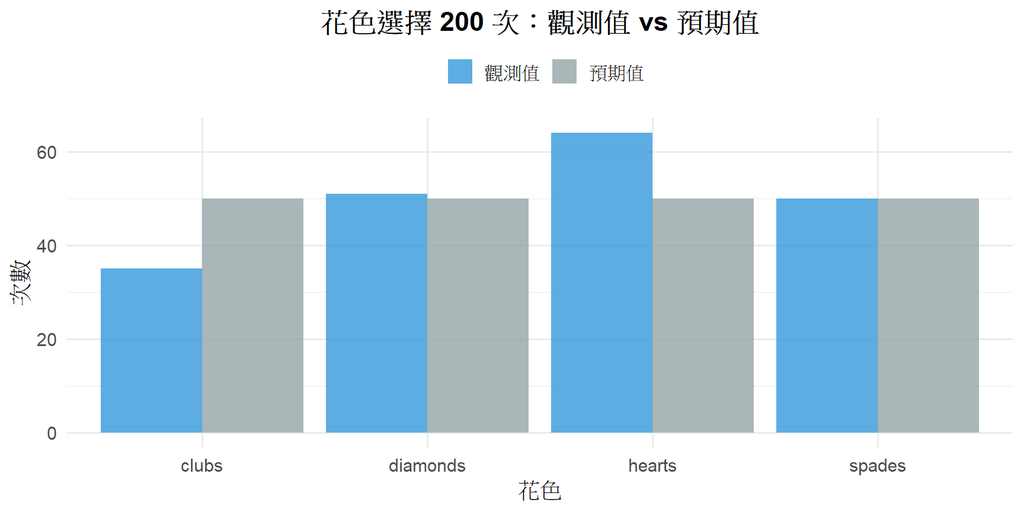

## 適合度檢定結果

$$\chi^2(3) = 8.44,\quad p =
0.038$$

$p = 0.038 < .05$ → **拒絕 H₀**：花色選擇非均等，有偏好

**自由度**：$df = k - 1 = 4 - 1 = 3$（k 為類別數）

## jamovi 操作：適合度檢定

**步驟**：

1. **Frequencies → N Outcomes → $\chi^2$ Goodness of fit**
2. 將類別變項拖入 **Variable**
3. 選擇 **Expected Proportions**（預設均等）
4. 查看結果表格中的 $\chi^2$、df、p

**注意**：

- 如果預期比例不均等，需手動設定每個類別的比例
- 例如：預期 A:B:C = 2:1:1 → 輸入 0.5, 0.25, 0.25

## jamovi 示範：隨機分派是否均等？

**來源**：Zhang et al. (2024) Study 2

64 位大學生隨機分派到三種教學條件：

| 條件 | 說明 | 實際人數 |
| --- | --- | --- |
| 0 | Static Slides（靜態投影片） | 24 |
| 1 | Drawing + Hand（顯手繪圖） | 17 |
| 2 | Drawing Only（無手繪圖） | 23 |

**研究問題**：三組人數是否符合均等分配（預期各 $\approx$ 21.3 人）？

> 運用適合度檢定：**隨機分派是否成功讓三組人數接近均等？**

# Part 3：獨立性檢定🧠

## Chapek9 資料集

**情境**：異星球入境旅客族群（human、robot）的回答偏好（data、flower 或 puppy）

Species × Choice 列聯表

|  | data | flower | puppy | Sum |
| --- | --- | --- | --- | --- |
| human | 65 | 13 | 15 | 93 |
| robot | 44 | 30 | 13 | 87 |
| Sum | 109 | 43 | 28 | 180 |

**問題**：旅客族群與回答偏好之間有關聯嗎？

- **$H_0$**：species 與 choice 獨立（無關聯）
- **$H_1$**：species 與 choice 不獨立（有關聯）

## 百分比堆疊條形圖

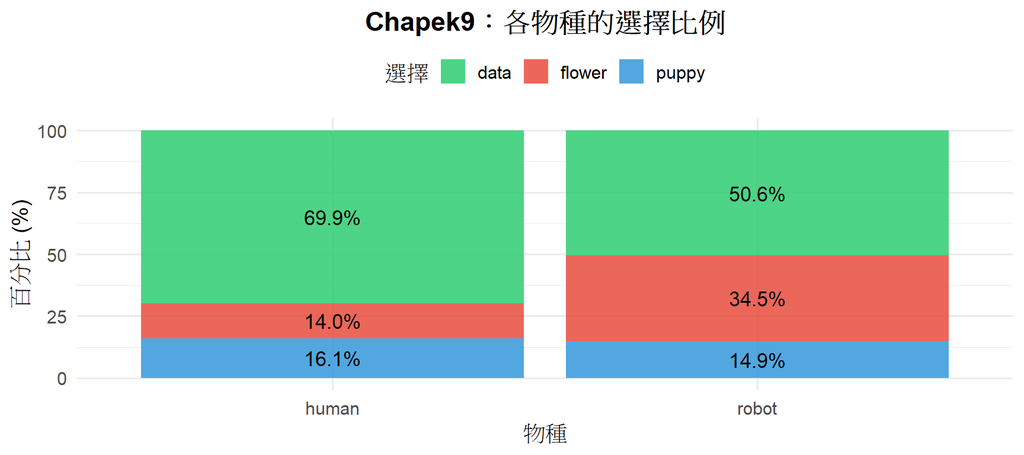

## 獨立性檢定的預期值

**預期值計算**：

$$E_{ij} = \frac{R_i \times
C_j}{N}$$

預期次數（假設 H₀ 為真）

|  | data | flower | puppy |
| --- | --- | --- | --- |
| human | 56.3 | 22.2 | 14.5 |
| robot | 52.7 | 20.8 | 13.5 |

> 預期值 = 「如果物種與選擇無關，各格子應該有多少人？」

## 獨立性檢定結果

$$\chi^2(2) = 10.72,\quad p = 0.005,\quad
V = 0.24$$

$p = 0.005 < .05$ → **拒絕 H₀**：物種與選擇有關聯

$V = 0.24$（小效果）

## 解讀列聯表的百分比

**行百分比**（Row %）

- 每一列加總 = 100%
- 回答：「在 robot 中，選 puppy 的比例是多少？」
- 用於比較**不同物種的選擇模式**

**列百分比**（Column %）

- 每一欄加總 = 100%
- 回答：「在選 puppy 的人中，robot 佔多少？」
- 用於比較**不同選擇的物種組成**

> jamovi 中可在 Contingency Tables 勾選 Row / Column percentages

## jamovi 操作：獨立性檢定

**步驟**：

1. **Frequencies → Contingency Tables → Independent Samples - $\chi^2$ test of association**
2. 將一個類別變項拖入 **Rows**，另一個拖入 **Columns**
3. 勾選 **Statistics → $\chi^2$**
4. 勾選 **Statistics → Cramer’s V**（效果量）
5. 勾選 **Cells → Expected counts**

## jamovi 示範：性別分配是否均衡？

**來源**：Zhang et al. (2024) Study 2

隨機分派後，三組的性別組成如下：

| 條件 | Female | Male |
| --- | --- | --- |
| Static Slides (0) | 13 | 11 |
| Drawing + Hand (1) | 14 | 3 |
| Drawing Only (2) | 19 | 4 |

**研究問題**：教學條件（condition）與性別（Sex）是否獨立？

> 運用獨立性檢定：**隨機分派是否讓三組參與者的性別組成均衡**

# Part 4：效果量與適用條件🧠

## Cramer’s V：關聯強度

$$V = \sqrt{\frac{\chi^2}{N \times (k -
1)}}$$

$k = \min(\text{列數}, \text{欄數})$

| Cramer’s V | 關聯強度 |
| --- | --- |
| .10 | 小 |
| .30 | 中 |
| .50 | 大 |

> V 的範圍：0（完全獨立）到 1（完全關聯）

## 適用條件：預期次數 ≥ 5

**規則**：每個細格的**預期次數** $E_{ij} \geq 5$

Chapek9 的預期次數

|  | data | flower | puppy |
| --- | --- | --- | --- |
| human | 56.3 | 22.2 | 14.5 |
| robot | 52.7 | 20.8 | 13.5 |

- 預期次數 < 5 的細格數：0

→ **所有預期次數 ≥ 5**，卡方檢定適用 ✓

## Fisher’s Exact Test

**何時使用**？

- 預期次數 < 5 的細格超過 **20%**
- 或任何一格預期次數 < 1

## Fisher’s Exact Test(續)

**jamovi 操作**：

- Contingency Tables → Statistics → 勾選 **Fisher’s exact test**

**差異**：

|  | 卡方檢定 | Fisher’s Exact |
| --- | --- | --- |
| 原理 | 近似法（大樣本） | 精確機率計算 |
| 適用 | 預期次數都 ≥ 5 | 小樣本或稀疏表格 |
| 結果 | $\chi^2$, df, p | 僅 p 值 |

# Part 5：t vs $\chi^2$ 使用時機🧠

## 判斷流程

```
你的依變項是什麼尺度？
         │
    ┌────┴────┐
    │         │
 連續       名義、次序
（分數、時間）（是/否、選擇）
    │         │
  t 檢定     卡方檢定
    │         │
    │         │
  效果量    效果量
    d         V
```

> **核心原則**：比**平均數** → t，比**比例/次數** → $\chi^2$

## 情境練習

| # | 情境 | 應使用 |
| --- | --- | --- |
| 1 | 比較男女生的考試**分數** | **t 檢定** |
| 2 | 比較男女生選文組/理組的**人數** | **卡方檢定** |
| 3 | 比較治療前後的焦慮**量表分數** | **相依 t** |
| 4 | 調查不同年齡層偏好的飲料**類型** | **卡方檢定** |

## 判斷的關鍵問句

問自己兩個問題：

1. **依變項是數字（連續）還是類別(名義、次序)？**
   - 數字 → t（或 ANOVA）
   - 類別 → $\chi^2$
2. **自變項(獨變項)有幾組？**
   - 1 組 vs 理論值 → 適合度 / 單一樣本 t
   - 2 組以上 → 獨立性 / 獨立樣本 t

# Part 6：本週作業

## 作業內容

**資料**：個人化 `W13_Survey_[學號].csv`

你的資料包含：

| 變項 | 類型 | 說明 |
| --- | --- | --- |
| `Member_Type` | Nominal | 會員類型（Regular / Premium / VIP） |
| `Store_Preference` | Nominal | 商店偏好（A / B / C / D） |
| `Satisfaction` | Nominal | 滿意度（Satisfied / Neutral / Dissatisfied） |

## 任務 1：適合度檢定

**操作**：檢驗 `Store_Preference` 是否均等分佈

1. **Frequencies → N Outcomes**
2. 檢視 $\chi^2$、df、p 值
3. 記錄觀測次數與預期次數

## 任務 2：獨立性檢定

**操作**：檢驗 `Member_Type` 與 `Satisfaction` 之間是否有關聯

1. **Frequencies → Contingency Tables**
2. 勾選 **$\chi^2$** + **Cramer’s V**
3. 勾選 **Expected counts**
4. 記錄列聯表與預期次數
5. 判斷是否有預期次數 < 5 的情況

## 任務 3：APA 寫作 + 觀念辨析

**APA 寫作**（2 段）：

1. 適合度檢定：$\chi^2(df) = \dots,\ p = \dots$
2. 獨立性檢定：$\chi^2(df) = \dots,\ p = \dots,\ V = \dots$

**觀念辨析**（3 題）：

1. **Q1**：請說明以下情境應使用 t 檢定還是卡方檢定，並解釋原因：
1. 比較男生和女生的考試成績平均分數
2. 調查中學生與大學生使用的社群軟體（IG/FB/TikTok）人數比例
3. 檢驗某家餐廳在google地圖評分在不同月份獲得的評等是否一致
2. **Q2**：為什麼預期次數太小（< 5）會導致卡方檢定不準確？此時應如何處理？
3. **Q3**：Cramer’s V = 0.15 與 V = 0.45 分別代表什麼？以卡法分佈的特性來說，為什麼光看 p 值是不夠的？

## 繳交要求

**檔案 1：學號_姓名_W13_Lab.omv**

- 含適合度檢定（Store_Preference）
- 含獨立性檢定（Member_Type × Satisfaction）
- 勾選 Expected Counts 與 Cramer’s V

**檔案 2：學號_姓名_W13_Report.docx**

- 適合度檢定結果
- 獨立性檢定結果 + 預期次數診斷
- 2 段 APA 格式報告
- 3 題觀念辨析

**繳交期限**：本週上課結束前

# 小結與展望

## 本週核心概念

1. **觀測 vs 預期**：$\chi^2 = \sum (O-E)^2 / E$
2. **適合度檢定**：一個變項的分佈是否符合預期
3. **獨立性檢定**：兩個類別變項是否有關聯
4. **效果量**：Cramer’s V（.1 小 / .3 中 / .5 大）
5. **適用條件**：預期次數 ≥ 5，否則用 Fisher’s Exact
6. **t vs $\chi^2$**：連續 → t，類別 → $\chi^2$

## 下週預告

**下週問題**：

- 兩個**連續變項**之間的關係？
- 什麼是**相關係數**？
- **相關 ≠ 因果**到底是什麼意思？

## 課後資源

**電子書**： [第 10 章：類別資料分析](https://scgeeker.github.io/lsj-book-zh_tw/10-Categorical-data-analysis.html)

**關鍵術語對照**：

| 中文 | 英文 | 符號 |
| --- | --- | --- |
| 卡方檢定 | Chi-square test | $\chi^2$ |
| 適合度檢定 | Goodness-of-fit test | — |
| 獨立性檢定 | Test of independence | — |
| 列聯表 | Contingency table | — |
| 預期次數 | Expected frequency | $E$ |
| 觀測次數 | Observed frequency | $O$ |
| 克拉瑪 V | Cramer’s V | $V$ |